# ESM 206 Lab 2

Allison Horst

October 3, 2018

### Lab 2 Objectives

- RMarkdown introduction (creating, some formatting, knitting)
- Data wrangling continued (rename, group_by, summarize)

### 1. What is markdown?

Introduce markdown. Point out differences between markdown and scripts. Why is this useful? Document preparation + embedded code - you can do everything in the same place (write, analyze, produce final figures…). That means better reproducibility.

### 2. Some basics in markdown formatting…

# One pound sign: Large heading

## More means smaller headings

Just writing text is regular text

We can *italicize* using a single asterisk Or **bold** using double asterisks

1. Or
2. make
3. numbered
4. lists

And when we’re ready to prepare a report, we press KNIT to convert to a supported document type (today we’ll use knitting to HTML)

But we can do all of that in a Word document. Why is markdown special? Because it allows us to do **all of our writing and data analysis and data visualization in the SAME PLACE!** Can you imagine not having 15 files with your different analyses, and a different Word document with your text, and different files for all of your figures? That is not an easy way to reproduce computational data science…

### 3. Embedding code into Rmarkdown (+ data wrangling review)

To add code in Rmarkdown, Insert an R code chunk (Insert > R) (or shortcut command + shift + i). You will see a new shaded region appear. That’s where you’ll include any active code AND commenting (you can treat these shaded areas like you would a script).

First, let’s load the tidyverse and our data (information on pesticide application in Santa Barbara county for wine grapes in 2016). Data is from the California Department of Pesticide Regulation’s Pesticide Information Portal (CALPIP).

```r
####### This area works like a script:

library(tidyverse) # Loads the tidyverse
```

```r
library(RColorBrewer) # (just for my graph example)

sb_pest <- read_csv("sb_pest.csv") # Read in the sb_pest.csv file
### DO NOT USE read.csv. USE read_csv().

####### Basic data exploration:

View(sb_pest)
names(sb_pest)
```

```
##  [1] "YEAR"                    "DATE"
##  [3] "COUNTY_NAME"             "COMTRS"
##  [5] "SITE_NAME"               "PRODUCT_NAME"
##  [7] "POUNDS_PRODUCT_APPLIED"  "CHEMICAL_NAME"
##  [9] "POUNDS_CHEMICAL_APPLIED" "AMOUNT_TREATED"
## [11] "UNIT_TREATED"            "AERIAL_GROUND_INDICATOR"
```

```r
summary(sb_pest) # At this point, make them look at the class of POUNDS_CHEMICAL_APPLIED. If is "character", that's fine...if it's "factor", then they'll want it to be character.
```

```
##       YEAR          DATE           COUNTY_NAME           COMTRS
##  Min.   :2016   Length:20637       Length:20637       Length:20637
##  1st Qu.:2016   Class :character   Class :character   Class :character
##  Median :2016   Mode  :character   Mode  :character   Mode  :character
##  Mean   :2016
##  3rd Qu.:2016
##  Max.   :2016
##
##   SITE_NAME         PRODUCT_NAME       POUNDS_PRODUCT_APPLIED
##  Length:20637       Length:20637       Min.   :    0.024
##  Class :character   Class :character   1st Qu.:    4.654
##  Mode  :character   Mode  :character   Median :   15.556
##                                        Mean   :   80.267
##                                        3rd Qu.:   50.528
##                                        Max.   :28999.856
##                                        NA's   :5
##  CHEMICAL_NAME      POUNDS_CHEMICAL_APPLIED AMOUNT_TREATED
##  Length:20637       Length:20637            Min.   :  0.08
##  Class :character   Class :character        1st Qu.:  6.78
##  Mode  :character   Mode  :character        Median : 18.87
##                                             Mean   : 44.26
##                                             3rd Qu.: 44.88
##                                             Max.   :636.00
##                                             NA's   :2
##  UNIT_TREATED       AERIAL_GROUND_INDICATOR
##  Length:20637       Length:20637
##  Class :character   Class :character
##  Mode  :character   Mode  :character
##
##
##
##
```

Looks like it loaded successfully. We’re only really interested in four variables: county (COUNTY_NAME), crop (SITE_NAME), chemical name (CHEMICAL_NAME), pounds of chemical applied (POUNDS_CHEMICAL_APPLIED).

First, let’s do the following: (1) Select only those columns (2) Rename the columns to something more useful (3) Remove rows with ‘NA’ in the pounds applied column (4) Re-order columns to county, chemical, pounds, crop (5) Coerce ‘pounds’ into class ‘numeric’

```r
# Basic data wrangling (review)

sb_simple <- sb_pest %>%
  select(COUNTY_NAME, SITE_NAME, CHEMICAL_NAME, POUNDS_CHEMICAL_APPLIED) %>%
  rename(county = COUNTY_NAME, crop = SITE_NAME, chemical = CHEMICAL_NAME, pounds = POUNDS_CHEMICAL_APPLIED) %>%
  filter(pounds != "N/A") %>% # Here, also show !is.na(pounds) option for NA
  select(county, chemical, pounds, crop) %>%
  mutate(pounds = as.numeric(pounds)) # In this case, it DOES overwrite

View(sb_simple)
class(sb_simple$pounds) # numeric
```

```
## [1] "numeric"
```

Now I’m back to working just in the document again. Remember to knit frequently to see what happens.

What if I don’t want my code or messages/outputs to show up in my knitted document? Then in the chunk header I can use things like ‘echo = FALSE’, ‘message = FALSE’, results = “hide”. Let’s see what happens:

```r
# Show what happens when you add the lines above and knit...
names(sb_simple)
```

```
## [1] "county"   "chemical" "pounds"   "crop"
```

### 4. Summary statistics and group_by()

```r
grapes_summary <- sb_simple %>%
  group_by(chemical) %>%
  summarize(
    total_applied = sum(pounds),
    max_applied = max(pounds)
  ) %>%
  arrange(-total_applied) %>%
  head(10)

grapes_summary
```

```
## # A tibble: 10 x 3
##    chemical                        total_applied max_applied
##    <chr>                                   <dbl>       <dbl>
##  1 SULFUR                                335144.       7070.
##  2 PETROLEUM DISTILLATES, REFINED        216733.       5777.
##  3 POTASSIUM BICARBONATE                  56168.       1148.
##  4 LIME-SULFUR                            48180.       8410.
##  5 MINERAL OIL                            13506.        382.
##  6 GLUFOSINATE-AMMONIUM                   12534.        352.
##  7 GLYPHOSATE, ISOPROPYLAMINE SALT        10624.        560.
##  8 COPPER HYDROXIDE                        8832.        277.
##  9 PENDIMETHALIN                           7169.       1807.
## 10 OXYFLUORFEN                             6720.        482.
```

You can also group by multiple variables (e.g. if we had multiple counties, we could group by county THEN by chemical, and we’d get a summary for pesticides by type and county)

What if I want to export that data frame as its own file (csv)? Use write_csv to send it to your working directory.

```r
write_csv(grapes_summary, "grapes_summary.csv")
```

Notice that it shows up in your ‘Files’ tab (working directory), and if you go to your project folder on your computer, it also exists there. Then you can copy/paste/email whatever.

Let’s make a column graph of the Top 10…

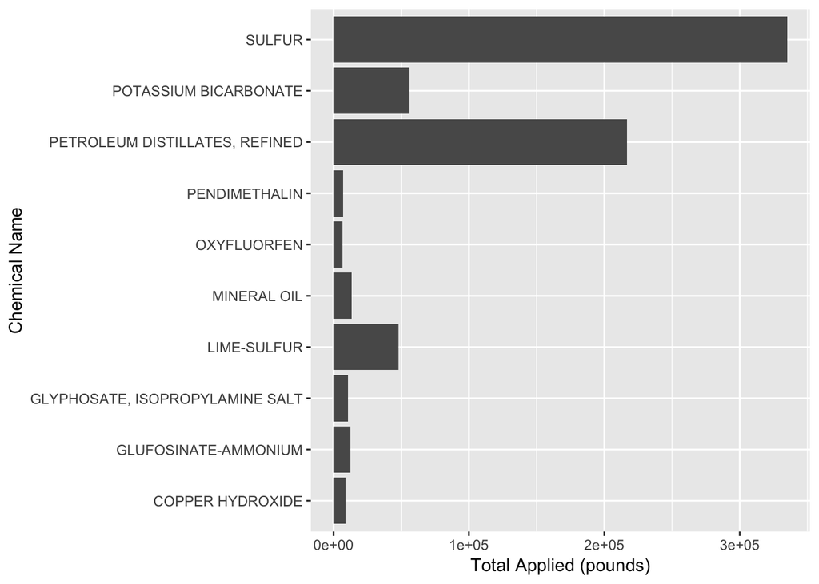

```r
top_10_col <- ggplot(grapes_summary,
                     aes(x = chemical,
                         y = total_applied)) +
  geom_col() +
  labs(x = "Chemical Name", y = "Total Applied (pounds)") +
  coord_flip()

top_10_col
```

```r
# Notice if we do this, it just puts them in alphabetical order. If we want it to stay in the order from high to low, we need to reassign the chemical as factors and explicitly set the levels (see below)

grape_summary_factor <- grapes_summary %>%
  mutate(chemical = factor(chemical, levels = chemical))

# NOW we can plot and that order will be retained...
```

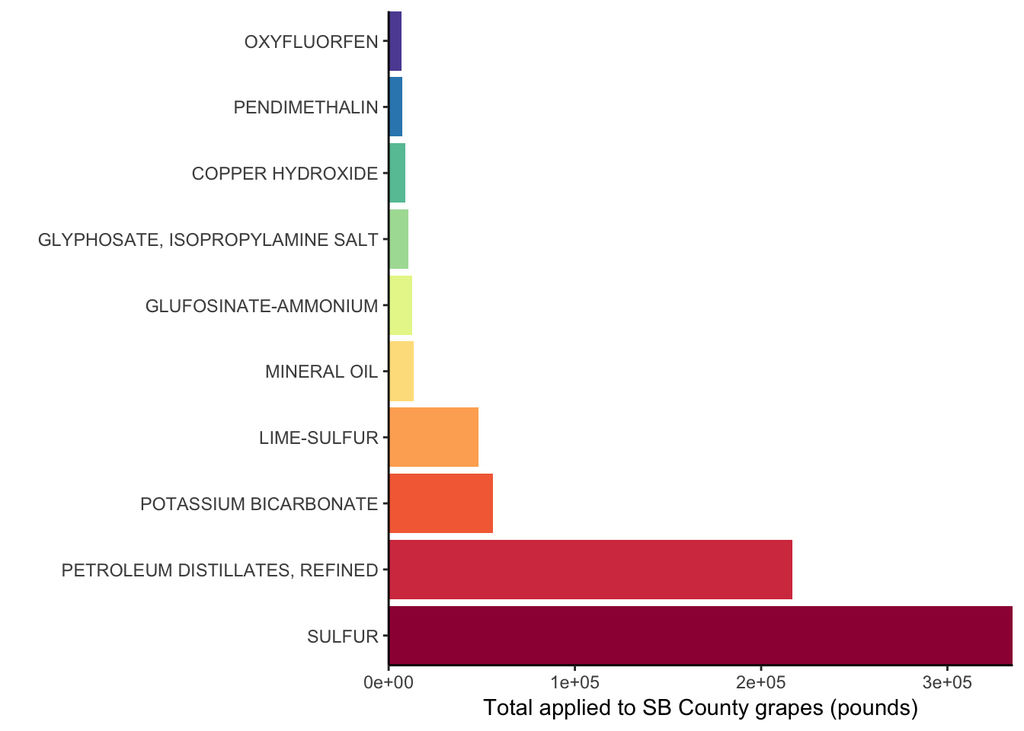

```r
top_10_ordered <- ggplot(grape_summary_factor, aes(x = chemical, y = total_applied)) +
  geom_col(aes(fill = chemical), show.legend = FALSE) +
  coord_flip() +
  scale_fill_brewer(palette = "Spectral") + # Note: need package RColorBrewer
  theme_classic() +
  scale_x_discrete(expand = c(0,0)) +
  scale_y_continuous(expand = c(0,0)) +
  labs(x = "", y = "Total applied to SB County grapes (pounds)")

top_10_ordered
```

### 5. A histogram (of glyphosate applications)

First, I’ll make a subset of sb_simple that only contains the application data for glyphosate (have THEM try this…the chemical is stored as GLYPHOSATE, ISOPROPYLAMINE SALT

```r
sb_glyphosate <- sb_simple %>%
  filter(chemical == "GLYPHOSATE, ISOPROPYLAMINE SALT")
```

Then make a histogram…

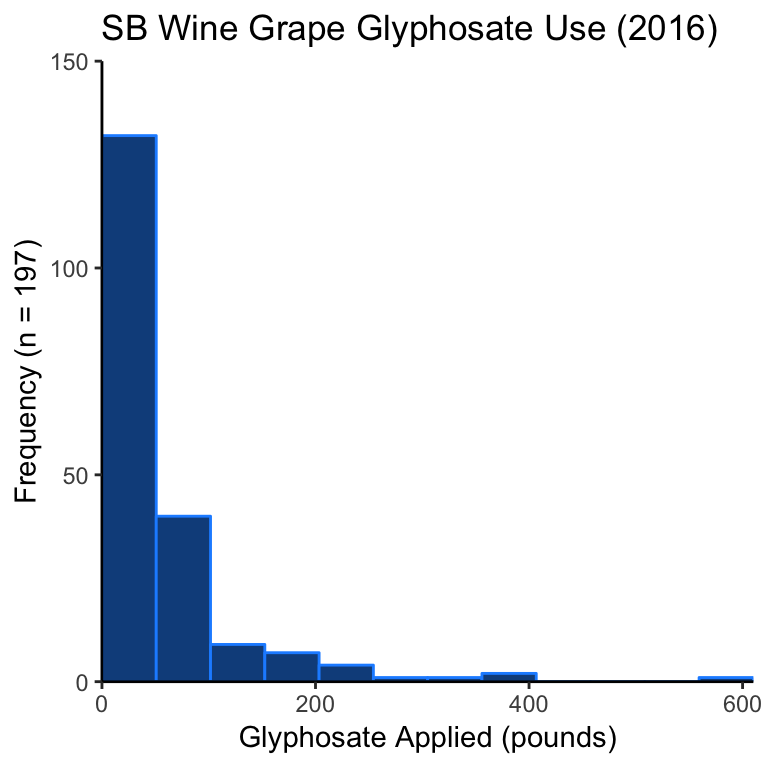

```r
glyphosate_hist <- ggplot(sb_glyphosate, aes(x = pounds)) +
  geom_histogram(bins = 12, boundary = 0, color = "dodgerblue", fill = "dodgerblue4") +
  labs(x = "Glyphosate Applied (pounds)",
       y = "Frequency (n = 197)",
       title = "SB Wine Grape Glyphosate Use (2016)") +
  theme_classic() +
  scale_y_continuous(expand = c(0,0), limits = c(0,150)) +
  scale_x_continuous(expand = c(0,0))


glyphosate_hist
```

Notice that when we knit, it shows up in that document (so we can embed final figures in a document, which will be automatically updated if we change our data/analyses/code…).

Want to change the size of the final figure in the knitted document? You can add fig.width or fig.height to the chunk header to specify (inches is default).

### 6. The datasets package and a boxplot

Want to do some practice with data analysis but don’t want to deal with loading data every time? There are some datasets that exist in R for just that purpose.

You can find them using library(help = “datasets”)…(run that in the console window). There are some pretty fun ones to practice with.

Let’s check out one of them: InsectSprays Use ?InsectSprays in the console to bring up information about the dataset

We want to make a boxplot (a different box + whisker for each of the different insect sprays)

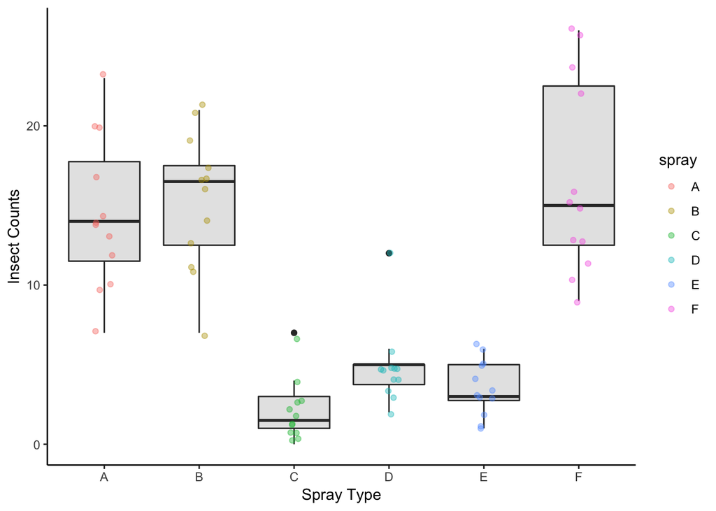

```r
insect_boxplot <- ggplot(InsectSprays, aes(x = spray, y = count)) +
  geom_boxplot(fill = "gray90") +
  theme_classic() +
  labs(x = "Spray Type", y = "Insect Counts") +
  geom_jitter(width = 0.1, alpha = 0.4, aes(color = spray))

insect_boxplot
```

To end: close entire project, reopen, run code: show how easy it is to recreate EVERYTHING just by running the entire code.

IF extra time: explore the ‘faithful’ dataset (use ?faithful). In ggplot, create a scatterplot of waiting time (x) versus eruption duration (y), and customize.

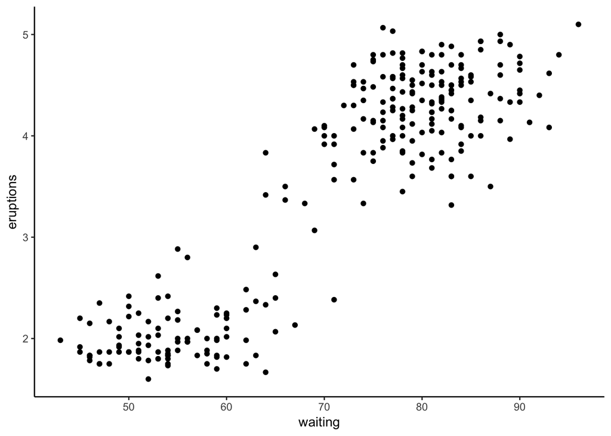

```r
faithful_plot <- ggplot(faithful, aes(x = waiting, y = eruptions)) +
  geom_point() +
  theme_classic()

faithful_plot
```

```r
# Always ask yourself: What are the major takeaways?
```